# 中文測試Survived or not

2017-09-27

# 1 Introduction 中文測試

This is an initial Exploratory Data Analysis for the [Titanic: Machine Learning from Disaster](https://www.kaggle.com/c/titanic) with [tidy R](http://tidyverse.org/) and [ggplot2](http://ggplot2.tidyverse.org/).

## 1.1 Load libraries and load data. 中文測試

`train.csv` and `test.csv` are [here](https://www.kaggle.com/c/titanic/data).

```r
# general visualisation
library('ggplot2') # visualisation
library('scales') # visualisation
library('grid') # visualisation
library('gridExtra') # visualisation
library('RColorBrewer') # visualisation
library('corrplot') # visualisation
library("cowplot") # visualisation
library("ggpubr")

# general data manipulation
library('dplyr') # data manipulation
library('readr') # input/output
library('data.table') # data manipulation
library('tibble') # data wrangling
library('tidyr') # data wrangling
library('stringr') # string manipulation
library('forcats') # factor manipulation
library("knitr") # data table

# Dates
library('lubridate') # date and time

# Extra vis
library('ggforce') # visualisation
library('ggridges') # visualisation

train <- fread("train.csv");
test <- fread("test.csv");
```

## 1.2 Data structure

- Train

```r
summary(train)
```

```
##   PassengerId       Survived          Pclass          Name
##  Min.   :  1.0   Min.   :0.0000   Min.   :1.000   Length:891
##  1st Qu.:223.5   1st Qu.:0.0000   1st Qu.:2.000   Class :character
##  Median :446.0   Median :0.0000   Median :3.000   Mode  :character
##  Mean   :446.0   Mean   :0.3838   Mean   :2.309
##  3rd Qu.:668.5   3rd Qu.:1.0000   3rd Qu.:3.000
##  Max.   :891.0   Max.   :1.0000   Max.   :3.000
##
##      Sex                 Age            SibSp           Parch
##  Length:891         Min.   : 0.42   Min.   :0.000   Min.   :0.0000
##  Class :character   1st Qu.:20.12   1st Qu.:0.000   1st Qu.:0.0000
##  Mode  :character   Median :28.00   Median :0.000   Median :0.0000
##                     Mean   :29.70   Mean   :0.523   Mean   :0.3816
##                     3rd Qu.:38.00   3rd Qu.:1.000   3rd Qu.:0.0000
##                     Max.   :80.00   Max.   :8.000   Max.   :6.0000
##                     NA's   :177
##     Ticket               Fare           Cabin             Embarked
##  Length:891         Min.   :  0.00   Length:891         Length:891
##  Class :character   1st Qu.:  7.91   Class :character   Class :character
##  Mode  :character   Median : 14.45   Mode  :character   Mode  :character
##                     Mean   : 32.20
##                     3rd Qu.: 31.00
##                     Max.   :512.33
##
```

```r
glimpse(train)
```

```
## Observations: 891
## Variables: 12
## $ PassengerId <int> 1, 2, 3, 4, 5, 6, 7, 8, 9, 10, 11, 12, 13, 14, 15,...
## $ Survived    <int> 0, 1, 1, 1, 0, 0, 0, 0, 1, 1, 1, 1, 0, 0, 0, 1, 0,...
## $ Pclass      <int> 3, 1, 3, 1, 3, 3, 1, 3, 3, 2, 3, 1, 3, 3, 3, 2, 3,...
## $ Name        <chr> "Braund, Mr. Owen Harris", "Cumings, Mrs. John Bra...
## $ Sex         <chr> "male", "female", "female", "female", "male", "mal...
## $ Age         <dbl> 22, 38, 26, 35, 35, NA, 54, 2, 27, 14, 4, 58, 20, ...
## $ SibSp       <int> 1, 1, 0, 1, 0, 0, 0, 3, 0, 1, 1, 0, 0, 1, 0, 0, 4,...
## $ Parch       <int> 0, 0, 0, 0, 0, 0, 0, 1, 2, 0, 1, 0, 0, 5, 0, 0, 1,...
## $ Ticket      <chr> "A/5 21171", "PC 17599", "STON/O2. 3101282", "1138...
## $ Fare        <dbl> 7.2500, 71.2833, 7.9250, 53.1000, 8.0500, 8.4583, ...
## $ Cabin       <chr> "", "C85", "", "C123", "", "", "E46", "", "", "", ...
## $ Embarked    <chr> "S", "C", "S", "S", "S", "Q", "S", "S", "S", "C", ...
```

- Test

```r
summary(test)
```

```
##   PassengerId         Pclass          Name               Sex
##  Min.   : 892.0   Min.   :1.000   Length:418         Length:418
##  1st Qu.: 996.2   1st Qu.:1.000   Class :character   Class :character
##  Median :1100.5   Median :3.000   Mode  :character   Mode  :character
##  Mean   :1100.5   Mean   :2.266
##  3rd Qu.:1204.8   3rd Qu.:3.000
##  Max.   :1309.0   Max.   :3.000
##
##       Age            SibSp            Parch           Ticket
##  Min.   : 0.17   Min.   :0.0000   Min.   :0.0000   Length:418
##  1st Qu.:21.00   1st Qu.:0.0000   1st Qu.:0.0000   Class :character
##  Median :27.00   Median :0.0000   Median :0.0000   Mode  :character
##  Mean   :30.27   Mean   :0.4474   Mean   :0.3923
##  3rd Qu.:39.00   3rd Qu.:1.0000   3rd Qu.:0.0000
##  Max.   :76.00   Max.   :8.0000   Max.   :9.0000
##  NA's   :86
##       Fare            Cabin             Embarked
##  Min.   :  0.000   Length:418         Length:418
##  1st Qu.:  7.896   Class :character   Class :character
##  Median : 14.454   Mode  :character   Mode  :character
##  Mean   : 35.627
##  3rd Qu.: 31.500
##  Max.   :512.329
##  NA's   :1
```

```r
glimpse(test)
```

```
## Observations: 418
## Variables: 11
## $ PassengerId <int> 892, 893, 894, 895, 896, 897, 898, 899, 900, 901, ...
## $ Pclass      <int> 3, 3, 2, 3, 3, 3, 3, 2, 3, 3, 3, 1, 1, 2, 1, 2, 2,...
## $ Name        <chr> "Kelly, Mr. James", "Wilkes, Mrs. James (Ellen Nee...
## $ Sex         <chr> "male", "female", "male", "male", "female", "male"...
## $ Age         <dbl> 34.5, 47.0, 62.0, 27.0, 22.0, 14.0, 30.0, 26.0, 18...
## $ SibSp       <int> 0, 1, 0, 0, 1, 0, 0, 1, 0, 2, 0, 0, 1, 1, 1, 1, 0,...
## $ Parch       <int> 0, 0, 0, 0, 1, 0, 0, 1, 0, 0, 0, 0, 0, 0, 0, 0, 0,...
## $ Ticket      <chr> "330911", "363272", "240276", "315154", "3101298",...
## $ Fare        <dbl> 7.8292, 7.0000, 9.6875, 8.6625, 12.2875, 9.2250, 7...
## $ Cabin       <chr> "", "", "", "", "", "", "", "", "", "", "", "", "B...
## $ Embarked    <chr> "Q", "S", "Q", "S", "S", "S", "Q", "S", "C", "S", ...
```

## 1.3 Missing values

- Train missing

```r
sum(is.na(train))
```

```
## [1] 177
```

- Test missing

```r
sum(is.na(test))
```

```
## [1] 87
```

## 1.4 Reformating variable.

- Ignore missing data temporarily.
- Survived reformate by as.factor and ignore PassengerId.
- Pclass, Sex and Embarked reformate by as.factor.
- Age, SibSp, Parch, Fare reformate by as.numeric.
- Remove punctuations of Name.
- Select the first word from Ticket.
- Cabin too many unknown, not good feature for survived.

```r
train <-
  train %>%
  na.omit %>%
  mutate(Survived = as.factor(Survived),
         Pclass = as.factor(Pclass),
         Sex = as.factor(Sex),
         Embarked = as.factor(Embarked),
         Age = as.numeric(Age),
         SibSp = as.numeric(SibSp),
         Parch = as.numeric(Parch),
         Fare = as.numeric(Fare)
         );
##  Reformate Name
train <- train %>%
  mutate(Name = gsub("[.,]", "", Name)) %>%
  mutate(Name = gsub("[[:punct:]]", "", Name));
##  Reformate Ticket
train <- train %>%
  mutate(Ticket = gsub("[. ]", "", Ticket)) %>%
  mutate(Ticket = gsub("[[:punct:]]", "", Ticket)) %>%
  mutate(Ticket = substr(Ticket, start=1, stop = 1)) %>%
  mutate(Ticket = as.factor(Ticket));

test <-
  test %>%
  na.omit %>%
  mutate(Pclass = as.factor(Pclass),
         Sex = as.factor(Sex),
         Embarked = as.factor(Embarked),
         Age = as.numeric(Age),
         SibSp = as.numeric(SibSp),
         Parch = as.numeric(Parch),
         Fare = as.numeric(Fare)
         );
##  Reformate Name
test <- test %>%
  mutate(Name = gsub("[.,]", "", Name)) %>%
  mutate(Name = gsub("[[:punct:]]", "", Name));
##  Reformate Ticket
test <- test %>%
  mutate(Ticket = gsub("[. ]", "", Ticket)) %>%
  mutate(Ticket = gsub("[[:punct:]]", "", Ticket)) %>%
  mutate(Ticket = substr(Ticket, start=1, stop = 1)) %>%
  mutate(Ticket = as.factor(Ticket));
```

# 2 Target

- Survived is less than died.
- The most people died from 3class.

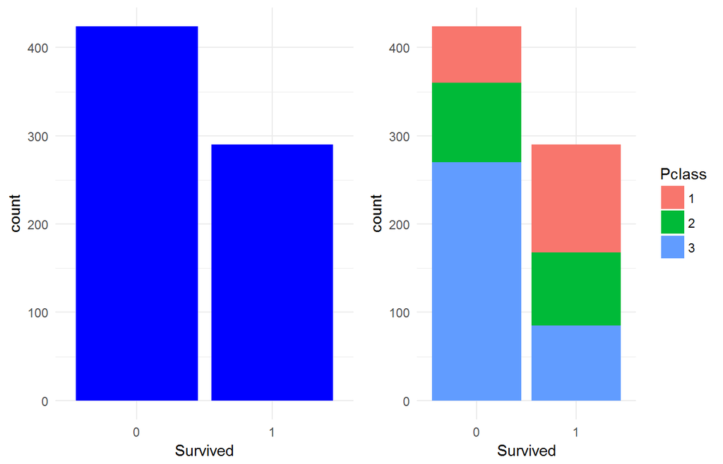

```r
p11 <- train %>%
  ggplot(aes(Survived, fill = Survived)) +
  geom_bar(fill = "blue") +
  theme(legend.position = "none") + theme_minimal();
p12 <- train %>%
  ggplot(aes(x = Survived, fill = Pclass)) +
  geom_bar() + theme_minimal()
figure11 <- ggarrange(p11, p12, ncol = 2, nrow = 1);
annotate_figure(figure11);
```

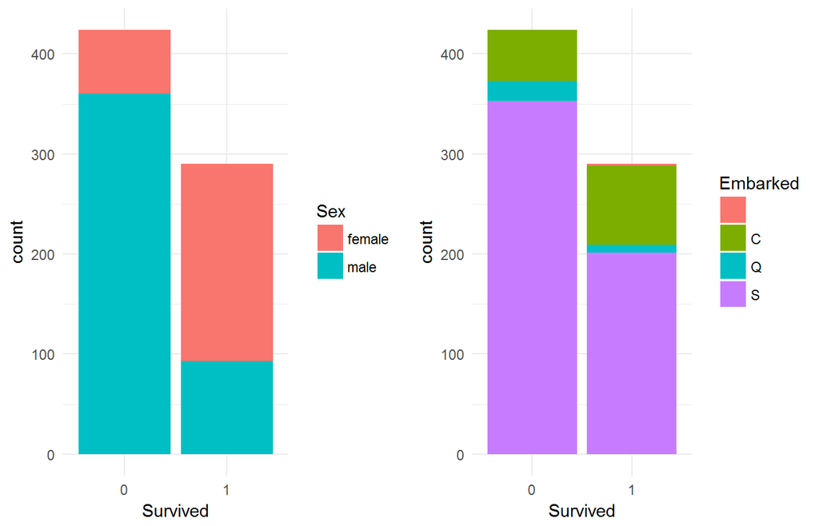

```r
p13 <- train %>%
  ggplot(aes(x = Survived, fill = Sex)) +
  geom_bar() + theme_minimal();
p14 <- train %>%
  ggplot(aes(x = Survived, fill = Embarked)) +
  geom_bar() + theme_minimal();
figure12 <- ggarrange(p13, p14, ncol = 2, nrow = 1);
annotate_figure(figure12);
```

- SibSp is 1, survived more than died.
- Parch is 1 and 2, survived more than died.

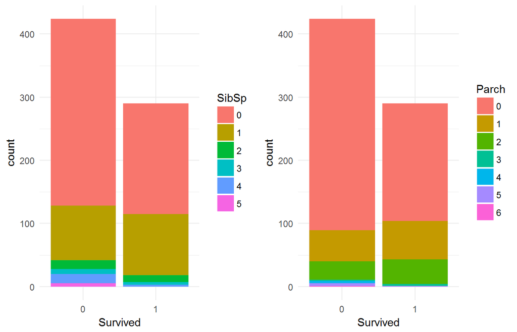

```r
p15 <- train %>%
  ggplot(aes(x = Survived, fill = as.factor(SibSp))) +
  geom_bar() + theme_minimal() + labs(fill = "SibSp");
p16 <- train %>%
  ggplot(aes(x = Survived, fill = as.factor(Parch))) +
  geom_bar() + theme_minimal() + labs(fill = "Parch");
figure13 <- ggarrange(p15, p16, ncol = 2, nrow = 1);
annotate_figure(figure13);
```

- More young childs are survived.
- More fare, more survived.

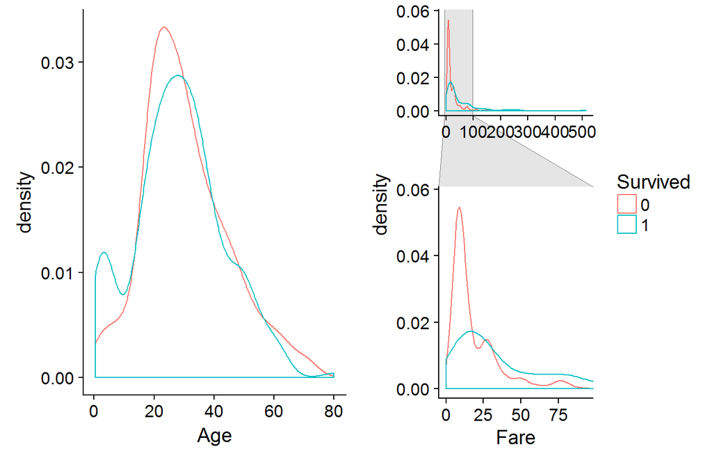

```r
p17 <- train %>%
  ggplot(aes(x = Age, colour = Survived)) + geom_density() +
  theme(legend.position = "none");
p18 <- train %>%
  ggplot(aes(x = Fare, colour = Survived)) + geom_density() +
  facet_zoom(x = Fare<100);
figure14 <- ggarrange(p17, p18, ncol = 2, nrow = 1);
annotate_figure(figure14);
```

```r
# train %>% ggplot(aes(x = Survived, fill = Ticket)) +
#   geom_bar(width = 0.9, position=position_dodge());
#
# wordcount <- train %>%
#   select(Name) %>%
#   lapply(function(x) strsplit(x," ")) %>%
#   unlist(use.names = F) %>%
#   table %>%
#   data.frame;
# colnames(wordcount) <- c("Word","Freq");
# subset(wordcount, Freq>10) %>%
#   ggplot(aes(Word, Freq)) +
#   geom_bar(stat="identity", fill="darkred", colour="darkgreen") +
#   theme(axis.text.x=element_text(angle=45, hjust=1)) +
#   labs(title = "Train");
# # figure15 <- ggarrange(p19, p110, ncol = 2, nrow = 1);
# # annotate_figure(figure15);
```

# 3 Individual variable visualisations

## 3.1 Pclass

- 3class is the most people.

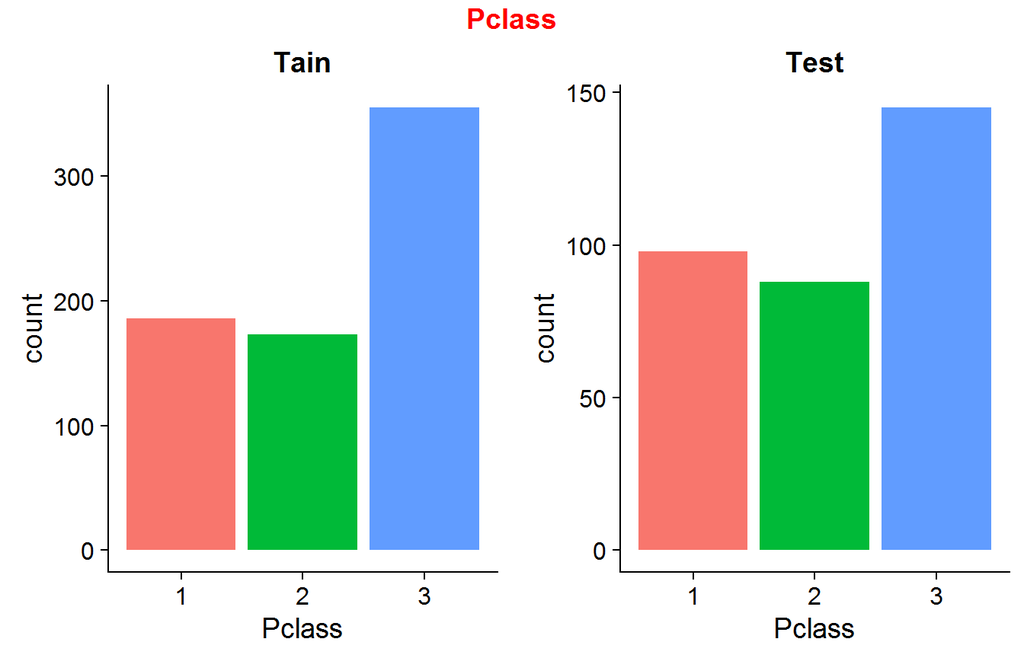

```r
p21 <- train %>%
  ggplot(aes(Pclass, fill = Pclass)) +
  geom_bar() +
  theme(legend.position = "none") +
  labs(title = "Tain");
p22 <- test %>%
  ggplot(aes(Pclass, fill = Pclass)) +
  geom_bar() +
  theme(legend.position = "none") +
  labs(title = "Test");
figure2 <- ggarrange(p21, p22, ncol = 2, nrow = 1);
annotate_figure(
  figure2,
  top = text_grob("Pclass", color = "red", face = "bold", size = 14)
);
```

## 3.2 Embarked

- Embarked from S is the most.
- Train have a few people that I don’t known where they embarked.

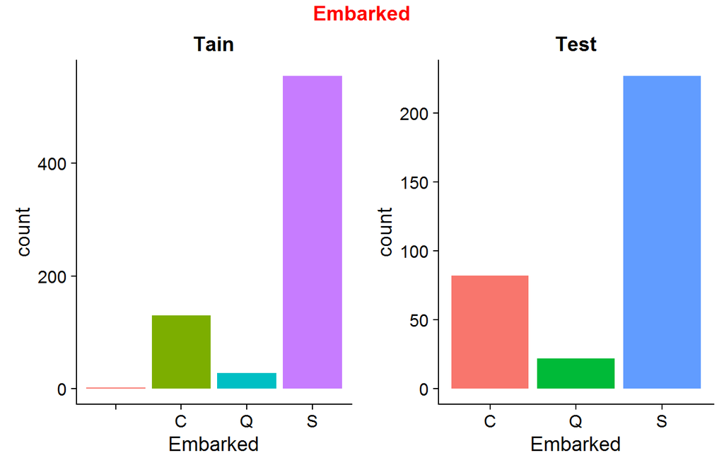

```r
p31 <- train %>%
  ggplot(aes(Embarked, fill = Embarked)) +
  geom_bar() +
  theme(legend.position = "none") +
  labs(title = "Tain");
p32 <- test %>%
  ggplot(aes(Embarked, fill = Embarked)) +
  geom_bar() +
  theme(legend.position = "none") +
  labs(title = "Test");
figure3 <- ggarrange(p31, p32, ncol = 2, nrow = 1);
annotate_figure(
  figure3,
  top = text_grob("Embarked", color = "red", face = "bold", size = 14)
);
```

## 3.3 Sex

- Male is more than female.

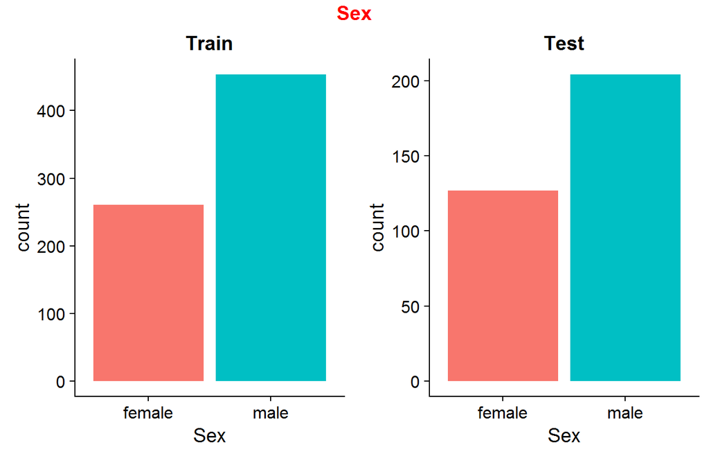

```r
p41 <- train %>%
  ggplot(aes(Sex, fill = Sex)) +
  geom_bar() +
  theme(legend.position = "none") +
  labs(title = "Train");
p42 <- test %>%
  ggplot(aes(Sex, fill = Sex)) +
  geom_bar() +
  theme(legend.position = "none") +
  labs(title = "Test");
figure4 <- ggarrange(p41, p42,
                     ncol = 2, nrow = 1);
annotate_figure(
  figure4,
  top = text_grob("Sex", color = "red", face = "bold", size = 14)
);
```

## 3.4 SibSp.

- Numeric type, but not more.
- Most people have 0 or 1.

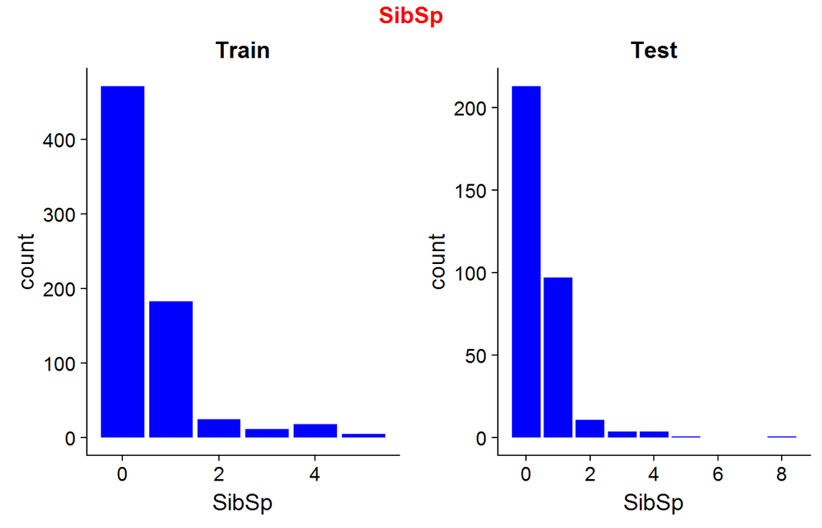

```r
p51 <- train %>%
  ggplot(aes(SibSp, fill = SibSp)) +
  geom_bar(fill = "blue") +
  theme(legend.position = "none") +
  labs(title = "Train");
p52 <- test %>%
  ggplot(aes(SibSp, fill = SibSp)) +
  geom_bar(fill = "blue") +
  theme(legend.position = "none") +
  labs(title = "Test");
figure5 <- ggarrange(p51, p52,
                     ncol = 2, nrow = 1);
annotate_figure(figure5,
                top = text_grob("SibSp", color = "red", face = "bold", size = 14));
```

## 3.5 Parch

- Numeric type, but not more.
- Most people have 0 or 1.

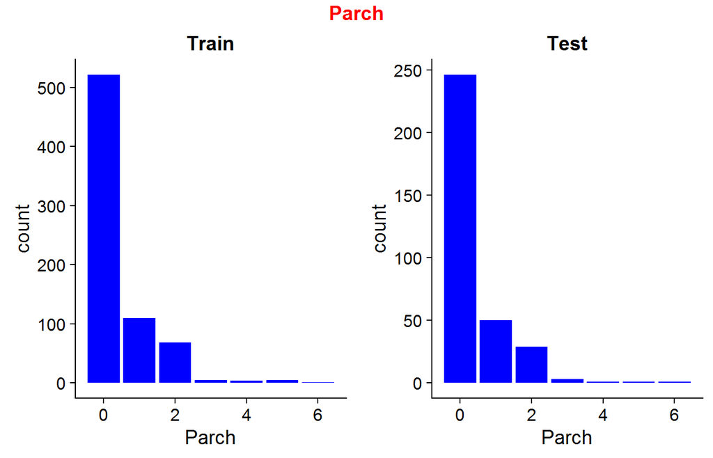

```r
p61 <- train %>%
  ggplot(aes(Parch, fill = Parch)) +
  geom_bar(fill = "blue") +
  theme(legend.position = "none") +
  labs(title = "Train");
p62 <- test %>%
  ggplot(aes(Parch, fill = Parch)) +
  geom_bar(fill = "blue") +
  theme(legend.position = "none") +
  labs(title = "Test");
figure6 <- ggarrange(p61,p62,
                     ncol = 2, nrow = 1);
annotate_figure(figure6,
                top = text_grob("Parch", color = "red", face = "bold", size = 14));
```

## 3.6 Age

- There are some childs.

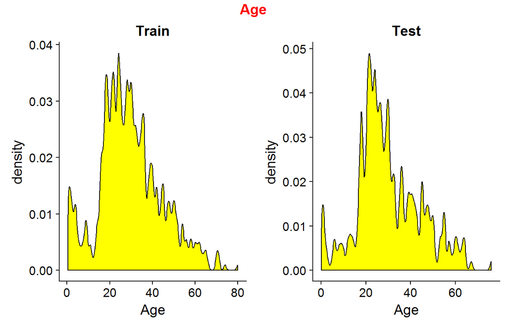

```r
p71 <- train %>%
  ggplot(aes(Age)) +
  geom_density(fill = "yellow", bw = 0.6) +
  labs(title = "Train");
p72 <- test %>%
  ggplot(aes(Age)) +
  geom_density(fill = "yellow", bw = 0.6) +
  labs(title = "Test");
figure7 <- ggarrange(p71,p72,ncol = 2, nrow = 1);
annotate_figure(figure7,
                top = text_grob("Age", color = "red", face = "bold", size = 14));
```

## 3.7 Fare

- The most fare is on [0,25].

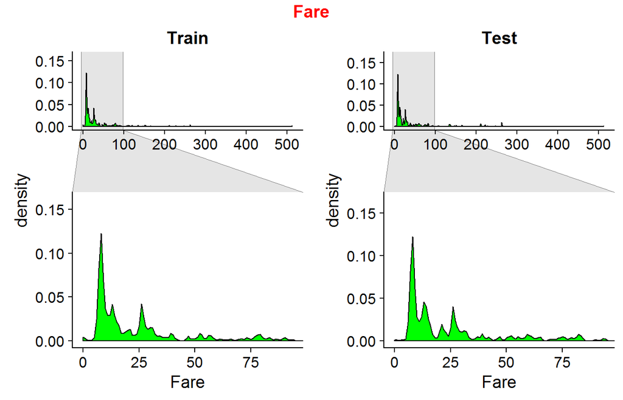

```r
p81 <- train %>%
  ggplot(aes(Fare)) +
  geom_density(fill = "green", bw = 0.6) +
  facet_zoom(x = (Fare)<100) +
  labs(title = "Train");
p82 <- test %>%
  ggplot(aes(Fare)) +
  geom_density(fill = "green", bw = 0.6) +
  facet_zoom(x = (Fare)<100) +
  labs(title = "Test");
figure8 <- ggarrange(p81, p82, ncol = 2, nrow = 1);
annotate_figure(figure8,
                top = text_grob("Fare", color = "red", face = "bold", size = 14));
```

## 3.8 Name

- There are some words frequency are high, like Mr, Mrs and Miss.

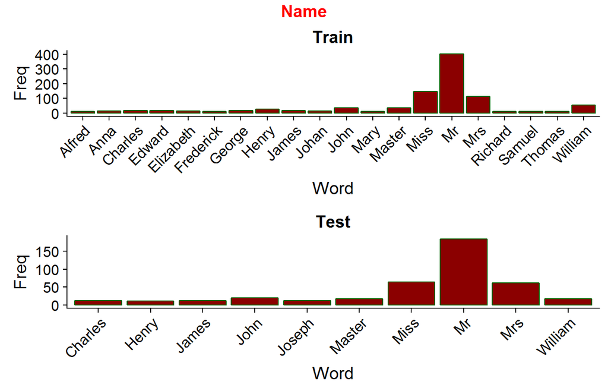

```r
wordcount <- train %>%
  select(Name) %>%
  lapply(function(x) strsplit(x," ")) %>%
  unlist(use.names = F) %>%
  table %>%
  data.frame;
colnames(wordcount) <- c("Word","Freq");
p91 <- subset(wordcount, Freq>10) %>%
  ggplot(aes(Word, Freq)) +
  geom_bar(stat="identity", fill="darkred", colour="darkgreen") +
  theme(axis.text.x=element_text(angle=45, hjust=1)) +
  labs(title = "Train");
wordcount <- test %>%
  select(Name) %>%
  lapply(function(x) strsplit(x," ")) %>%
  unlist(use.names = F) %>%
  table %>%
  data.frame;
colnames(wordcount) <- c("Word","Freq");
p92 <- subset(wordcount, Freq>10) %>%
  ggplot(aes(Word, Freq)) +
  geom_bar(stat="identity", fill="darkred", colour="darkgreen") +
  theme(axis.text.x=element_text(angle=45, hjust=1)) +
  labs(title = "Test");
figure9 <- ggarrange(p91, p92, ncol = 1, nrow = 2);
annotate_figure(figure9,
                top = text_grob("Name", color = "red", face = "bold", size = 14));
```

## 3.9 Ticket

- Ticket with the first word, I find 1, 2, 3 are the most and A, C, P, S have many.

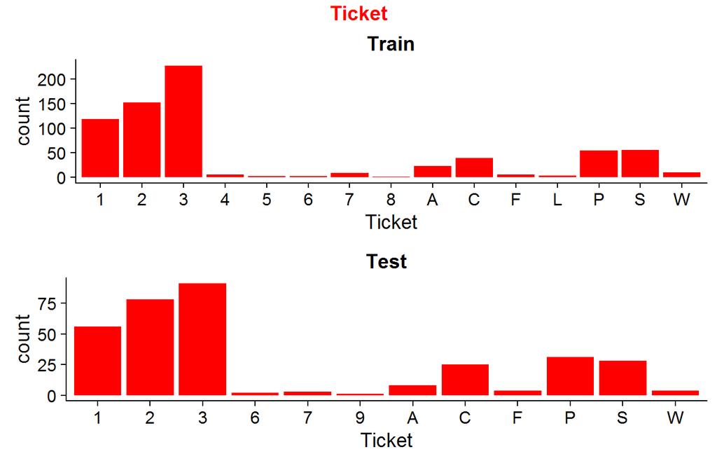

```r
p101 <- train %>%
  ggplot(aes(Ticket)) + geom_bar(fill = "red") +
  labs(title = "Train");
p102 <- test %>%
  ggplot(aes(Ticket)) + geom_bar(fill = "red") +
  labs(title = "Test");
figure10 <- ggarrange(p101, p102, ncol = 1, nrow = 2);
annotate_figure(figure10,
                top = text_grob("Ticket", color = "red", face = "bold", size = 14));
```